# RMarkdown Interactive Webpage Example

This page demonstates some nice functionality built both within and outside of R to generate multi-faceted, rich reports. The following is a **synthetic** report about Firefox add-ons, which is my focus as a member of Mozilla’s product data science team.

## Tables

Do you even need a plot? Sometimes the answer is no, and if you can load a `csv` or the like into R you can render a nice html table using the `kableExtra` + `knitr` packages.

```r
# make some fake data
fakeAggregates <- data.frame(
  addons=c(24.5, 3.4),
  no.addons=c(20.1, 2.3)
)
colnames(fakeAggregates) <- c("Addons", "No Addons")
rownames(fakeAggregates) <- c("Mean Session Length", "Mean Number of Sessions")

# render html table
fakeAggregates %>%
kable("html", escape=F) %>%
  kable_styling(bootstrap_options = c("striped", "hover"), full_width=F, font_size=25)
```

|  | Addons | No Addons |
| --- | --- | --- |
| Mean Session Length | 24.5 | 20.1 |
| Mean Number of Sessions | 3.4 | 2.3 |

## Static Plots

Before getting all fancy, I evaluate the `ggplot2` package to see if a simple, static plot will convey the information I want (usually it can!). This package has **tons** of customization options should you spend the time to read its [docs](http://ggplot2.tidyverse.org/reference/) :). Below is some more fake data from a hypothetical experiment.

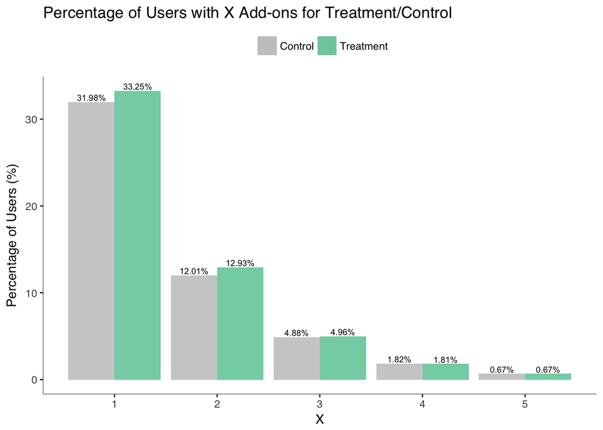

```r
generateFakeDataHist <- function(n) {
  histData <- data.frame(
    bucket=rep(1:n, 2),
    freq=100/(exp(rep(1:n, 2))+ (runif(1:(n*2)))),
    group=c(rep('Treatment', n), rep('Control', n))
  )
  histData
}

# how many buckets for the histogram?
N <- 5

# get some fake data
histData <- generateFakeDataHist(N)

# build the plot
p <- ggplot(histData) +
  geom_col(aes(x=bucket, y=freq, fill=group), alpha=.6, position="dodge") +
  theme(axis.line = element_line(colour = "#B3B2B2"),
        panel.grid.major = element_blank(),
        panel.grid.minor = element_blank(),
        panel.border = element_blank(),
        panel.background = element_blank(),
        legend.position = "top",
        legend.title = element_blank(),
        text = element_text(family='sans')) +
  labs(x="X", y="Percentage of Users (%)", title="Percentage of Users with X Add-ons for Treatment/Control") +
  scale_x_continuous(breaks=1:N) +
  scale_fill_manual("legend", values = c("Treatment" = "#05b378", "Control" = "#acabab"))

# add some text annotations
p + geom_text(data=histData, aes(x=bucket, y=freq, group=group,
                label=paste(round(freq, 2), "%", sep='')),
            position=position_dodge(.9), vjust=-.25, size=2.5,)
```

## Embedded HTML

Okay, so a table and a static plot aren’t doing the trick? We can develop plots using, say, [`D3.js`](https://d3js.org/) outside of rmarkdown, and then link them into the resulting webpage. The following examples are generated with the [`metricsgraphics.js`](https://www.metricsgraphicsjs.org/) package, which is a wrapper for D3 that focuses on time series visualization.

This is useful for reporting metrics over time, without crowding the plot with a bunch of text annotations.

```r
htmltools::includeHTML('./html/mg-charts.html')
```

[output not shown]